# SQ w22

## Shared Qs (w22)

#### Question

1. Match the five histograms with their appropriate description.

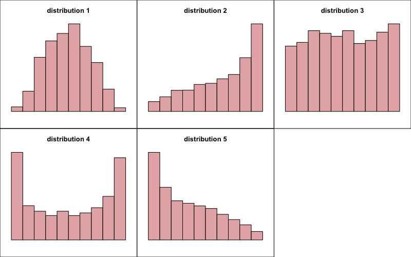

   - Bimodal:
   - Uniform:
   - Left-skew:
   - Bell:
   - Right-skew:

#### Solution

#### Question

2. Match the five histograms with their appropriate description.

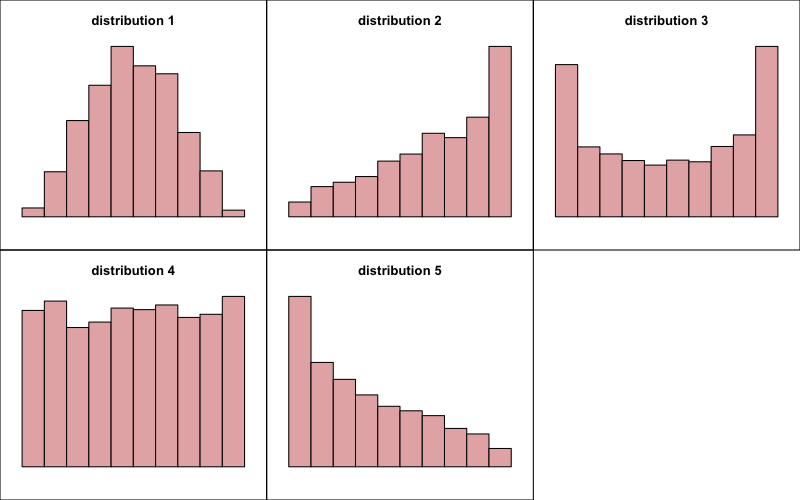

   - Bell:
   - Bimodal:
   - Left-skew:
   - Uniform:
   - Right-skew:

#### Solution

#### Question

3. Match the five histograms with their appropriate description.

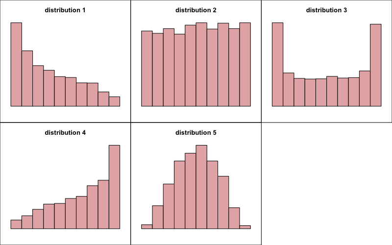

   - Left-skew:
   - Bell:
   - Uniform:
   - Right-skew:
   - Bimodal:

#### Solution

#### Question

4. Match the five histograms with their appropriate description.

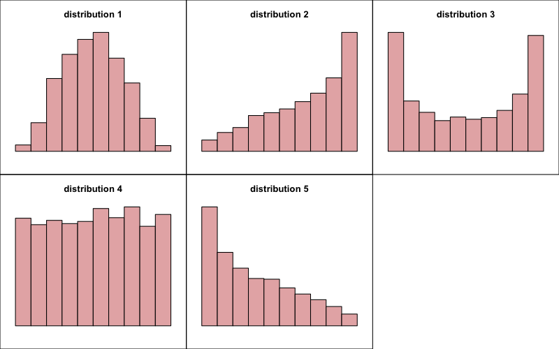

   - Left-skew:
   - Bell:
   - Right-skew:
   - Bimodal:
   - Uniform:

#### Solution

#### Question

5. Match the five histograms with their appropriate description.

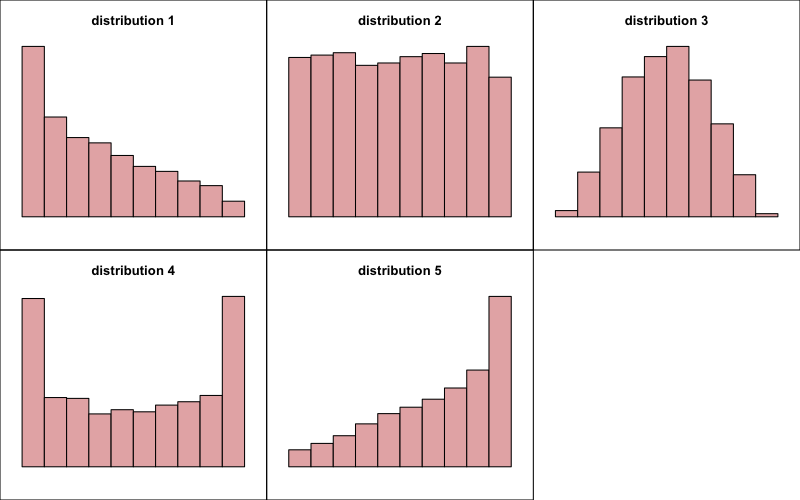

   - Uniform:
   - Right-skew:
   - Bimodal:
   - Left-skew:
   - Bell:

#### Solution

#### Question

6. Match the five histograms with their appropriate description.

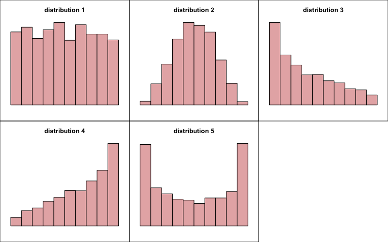

   - Left-skew:
   - Bell:
   - Right-skew:
   - Uniform:
   - Bimodal:

#### Solution

#### Question

7. Match the five histograms with their appropriate description.

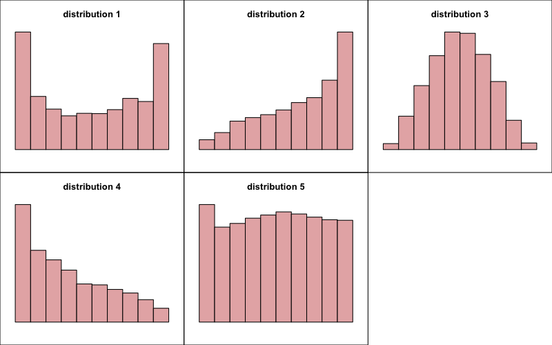

   - Bimodal:
   - Left-skew:
   - Right-skew:
   - Bell:
   - Uniform:

#### Solution

#### Question

8. Match the five histograms with their appropriate description.

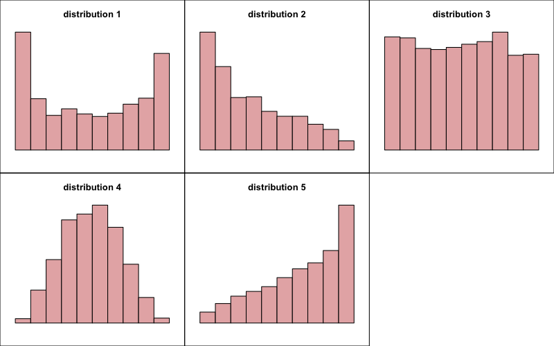

   - Bell:
   - Right-skew:
   - Bimodal:
   - Left-skew:
   - Uniform:

#### Solution

#### Question

9. Match the five histograms with their appropriate description.

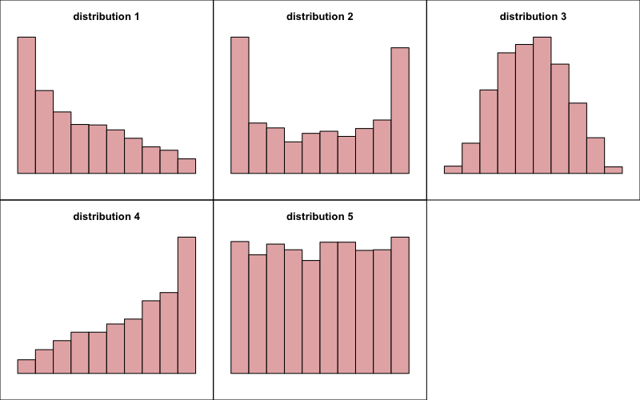

   - Uniform:
   - Right-skew:
   - Left-skew:
   - Bell:
   - Bimodal:

#### Solution

#### Question

10. Match the five histograms with their appropriate description.

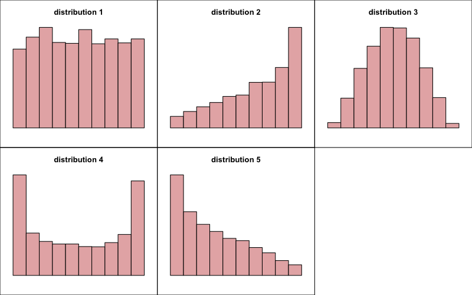

    - Bell:
    - Right-skew:
    - Uniform:
    - Bimodal:
    - Left-skew:

#### Solution

#### Question

11. Find [the mean](https://en.wikipedia.org/wiki/Arithmetic_mean) of the following list:
    $$42, 48, 44, 49, 41$$

    (Do not round your answer.)

#### Solution

#### Question

12. Find [the mean](https://en.wikipedia.org/wiki/Arithmetic_mean) of the following list:
    $$75, 72, 71, 73, 70$$

    (Do not round your answer.)

#### Solution

#### Question

13. Find [the mean](https://en.wikipedia.org/wiki/Arithmetic_mean) of the following list:
    $$92, 99, 97, 94, 90$$

    (Do not round your answer.)

#### Solution

#### Question

14. Find [the mean](https://en.wikipedia.org/wiki/Arithmetic_mean) of the following list:
    $$95, 99, 94, 91$$

    (Do not round your answer.)

#### Solution

#### Question

15. Find [the mean](https://en.wikipedia.org/wiki/Arithmetic_mean) of the following list:
    $$43, 47, 45, 48$$

    (Do not round your answer.)

#### Solution

#### Question

16. Find [the mean](https://en.wikipedia.org/wiki/Arithmetic_mean) of the following list:
    $$84, 82, 83, 80, 89$$

    (Do not round your answer.)

#### Solution

#### Question

17. Find [the mean](https://en.wikipedia.org/wiki/Arithmetic_mean) of the following list:
    $$52, 58, 57, 51, 54$$

    (Do not round your answer.)

#### Solution

#### Question

18. Find [the mean](https://en.wikipedia.org/wiki/Arithmetic_mean) of the following list:
    $$55, 59, 56, 51$$

    (Do not round your answer.)

#### Solution

#### Question

19. Find [the mean](https://en.wikipedia.org/wiki/Arithmetic_mean) of the following list:
    $$33, 36, 32, 39, 37, 30$$

    (Do not round your answer.)

#### Solution

#### Question

20. Find [the mean](https://en.wikipedia.org/wiki/Arithmetic_mean) of the following list:
    $$95, 94, 92, 98$$

    (Do not round your answer.)

#### Solution

#### Question

21. Find [the median](https://en.wikipedia.org/wiki/Median) of the following list:
    $$28, 27, 22, 24$$

    (Do not round your answer.)

#### Solution

#### Question

22. Find [the median](https://en.wikipedia.org/wiki/Median) of the following list:
    $$76, 79, 72, 70, 77, 73, 74$$

    (Do not round your answer.)

#### Solution

#### Question

23. Find [the median](https://en.wikipedia.org/wiki/Median) of the following list:
    $$68, 65, 63, 69$$

    (Do not round your answer.)

#### Solution

#### Question

24. Find [the median](https://en.wikipedia.org/wiki/Median) of the following list:
    $$32, 39, 34, 38, 37, 33, 35$$

    (Do not round your answer.)

#### Solution

#### Question

25. Find [the median](https://en.wikipedia.org/wiki/Median) of the following list:
    $$68, 64, 63, 69, 61, 60$$

    (Do not round your answer.)

#### Solution

#### Question

26. Find [the median](https://en.wikipedia.org/wiki/Median) of the following list:
    $$90, 93, 99, 96, 94$$

    (Do not round your answer.)

#### Solution

#### Question

27. Find [the median](https://en.wikipedia.org/wiki/Median) of the following list:
    $$41, 48, 42, 40, 49, 45$$

    (Do not round your answer.)

#### Solution

#### Question

28. Find [the median](https://en.wikipedia.org/wiki/Median) of the following list:
    $$68, 69, 61, 60$$

    (Do not round your answer.)

#### Solution

#### Question

29. Find [the median](https://en.wikipedia.org/wiki/Median) of the following list:
    $$53, 52, 59, 58, 50, 55, 51$$

    (Do not round your answer.)

#### Solution

#### Question

30. Find [the median](https://en.wikipedia.org/wiki/Median) of the following list:
    $$25, 28, 27, 21, 24, 22, 29$$

    (Do not round your answer.)

#### Solution

#### Question

31. Depending on the type of distribution, we can make a strong claim regarding the mean and median.
    - Symmetric (bell, uniform, bimodal)
      - $\text{mean} \approx \text{median}$
    - Skew-right
      - $\text{mean} > \text{median}$
    - Skew-left
      - $\text{mean} < \text{median}$

    A sample was gathered and visualized with a histogram.

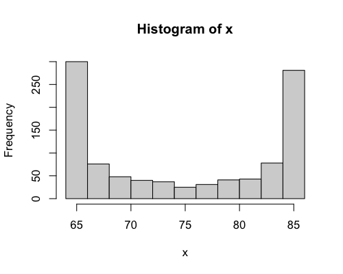

    What claim can you make regarding the mean and median?
    1. $\text{mean} \approx \text{median}$
    2. $\text{mean} > \text{median}$
    3. $\text{mean} < \text{median}$

#### Solution

#### Question

32. Depending on the type of distribution, we can make a strong claim regarding the mean and median.
    - Symmetric (bell, uniform, bimodal)
      - $\text{mean} \approx \text{median}$
    - Skew-right
      - $\text{mean} > \text{median}$
    - Skew-left
      - $\text{mean} < \text{median}$

    A sample was gathered and visualized with a histogram.

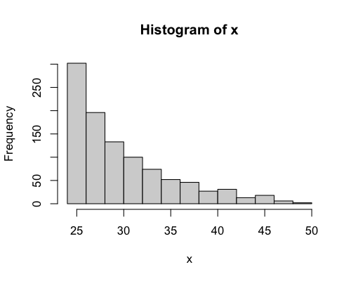

    What claim can you make regarding the mean and median?
    1. $\text{mean} \approx \text{median}$
    2. $\text{mean} > \text{median}$
    3. $\text{mean} < \text{median}$

#### Solution

#### Question

33. Depending on the type of distribution, we can make a strong claim regarding the mean and median.
    - Symmetric (bell, uniform, bimodal)
      - $\text{mean} \approx \text{median}$
    - Skew-right
      - $\text{mean} > \text{median}$
    - Skew-left
      - $\text{mean} < \text{median}$

    A sample was gathered and visualized with a histogram.

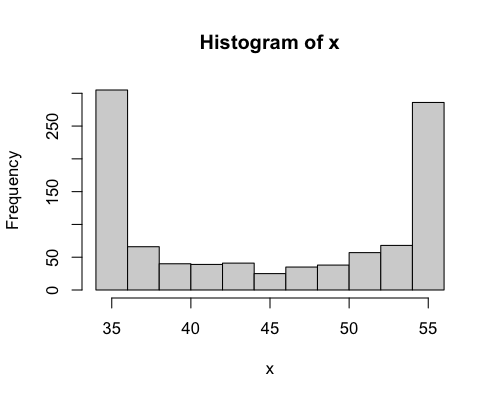

    What claim can you make regarding the mean and median?
    1. $\text{mean} \approx \text{median}$
    2. $\text{mean} > \text{median}$
    3. $\text{mean} < \text{median}$

#### Solution

#### Question

34. Depending on the type of distribution, we can make a strong claim regarding the mean and median.
    - Symmetric (bell, uniform, bimodal)
      - $\text{mean} \approx \text{median}$
    - Skew-right
      - $\text{mean} > \text{median}$
    - Skew-left
      - $\text{mean} < \text{median}$

    A sample was gathered and visualized with a histogram.

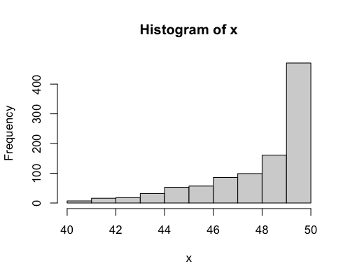

    What claim can you make regarding the mean and median?
    1. $\text{mean} \approx \text{median}$
    2. $\text{mean} > \text{median}$
    3. $\text{mean} < \text{median}$

#### Solution

#### Question

35. Depending on the type of distribution, we can make a strong claim regarding the mean and median.
    - Symmetric (bell, uniform, bimodal)
      - $\text{mean} \approx \text{median}$
    - Skew-right
      - $\text{mean} > \text{median}$
    - Skew-left
      - $\text{mean} < \text{median}$

    A sample was gathered and visualized with a histogram.

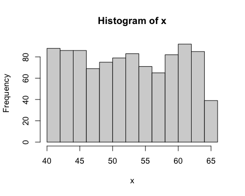

    What claim can you make regarding the mean and median?
    1. $\text{mean} \approx \text{median}$
    2. $\text{mean} > \text{median}$
    3. $\text{mean} < \text{median}$

#### Solution

#### Question

36. Depending on the type of distribution, we can make a strong claim regarding the mean and median.
    - Symmetric (bell, uniform, bimodal)
      - $\text{mean} \approx \text{median}$
    - Skew-right
      - $\text{mean} > \text{median}$
    - Skew-left
      - $\text{mean} < \text{median}$

    A sample was gathered and visualized with a histogram.

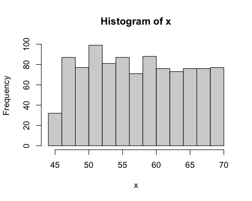

    What claim can you make regarding the mean and median?
    1. $\text{mean} \approx \text{median}$
    2. $\text{mean} > \text{median}$
    3. $\text{mean} < \text{median}$

#### Solution

#### Question

37. Depending on the type of distribution, we can make a strong claim regarding the mean and median.
    - Symmetric (bell, uniform, bimodal)
      - $\text{mean} \approx \text{median}$
    - Skew-right
      - $\text{mean} > \text{median}$
    - Skew-left
      - $\text{mean} < \text{median}$

    A sample was gathered and visualized with a histogram.

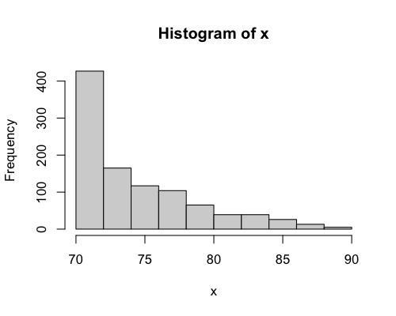

    What claim can you make regarding the mean and median?
    1. $\text{mean} \approx \text{median}$
    2. $\text{mean} > \text{median}$
    3. $\text{mean} < \text{median}$

#### Solution

#### Question

38. Depending on the type of distribution, we can make a strong claim regarding the mean and median.
    - Symmetric (bell, uniform, bimodal)
      - $\text{mean} \approx \text{median}$
    - Skew-right
      - $\text{mean} > \text{median}$
    - Skew-left
      - $\text{mean} < \text{median}$

    A sample was gathered and visualized with a histogram.

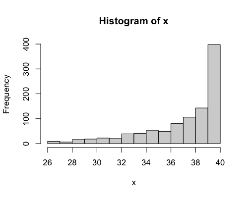

    What claim can you make regarding the mean and median?
    1. $\text{mean} \approx \text{median}$
    2. $\text{mean} > \text{median}$
    3. $\text{mean} < \text{median}$

#### Solution

#### Question

39. Depending on the type of distribution, we can make a strong claim regarding the mean and median.
    - Symmetric (bell, uniform, bimodal)
      - $\text{mean} \approx \text{median}$
    - Skew-right
      - $\text{mean} > \text{median}$
    - Skew-left
      - $\text{mean} < \text{median}$

    A sample was gathered and visualized with a histogram.

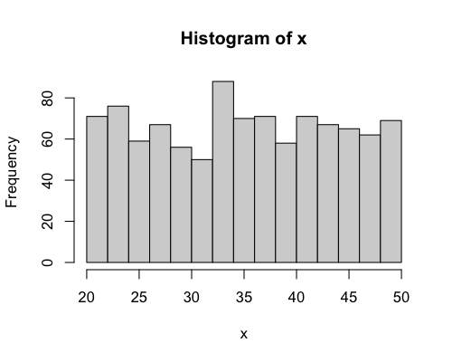

    What claim can you make regarding the mean and median?
    1. $\text{mean} \approx \text{median}$
    2. $\text{mean} > \text{median}$
    3. $\text{mean} < \text{median}$

#### Solution

#### Question

40. Depending on the type of distribution, we can make a strong claim regarding the mean and median.
    - Symmetric (bell, uniform, bimodal)
      - $\text{mean} \approx \text{median}$
    - Skew-right
      - $\text{mean} > \text{median}$
    - Skew-left
      - $\text{mean} < \text{median}$

    A sample was gathered and visualized with a histogram.

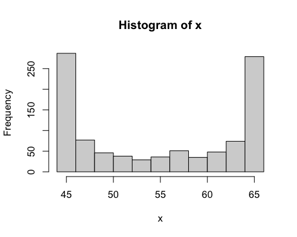

    What claim can you make regarding the mean and median?
    1. $\text{mean} \approx \text{median}$
    2. $\text{mean} > \text{median}$
    3. $\text{mean} < \text{median}$

#### Solution

#### Question

41. Five different populations were sampled, and the measurements were visualized as five [boxplots](https://en.wikipedia.org/wiki/Box_plot). (Note: typical boxplots indicate outliers with dots. For simplicity, these boxplots include all outliers in the whiskers.)

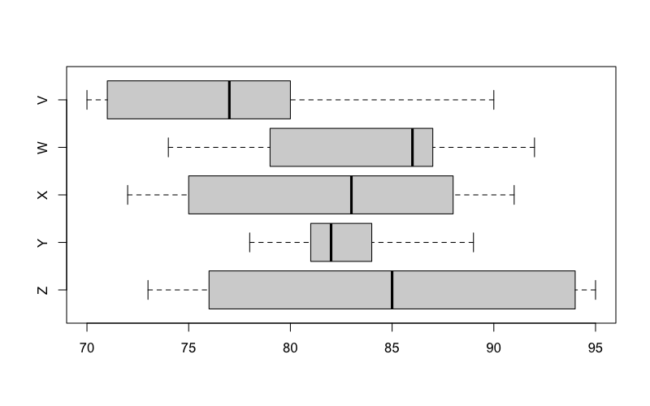

    1. Which sample contains the largest value?
    2. Which sample contains the smallest value?
    3. Which sample has the largest median?
    4. Which sample has the smallest median?
    5. Which sample has the largest IQR?
    6. Which sample has the smallest IQR?

#### Solution

#### Question

42. Five different populations were sampled, and the measurements were visualized as five [boxplots](https://en.wikipedia.org/wiki/Box_plot). (Note: typical boxplots indicate outliers with dots. For simplicity, these boxplots include all outliers in the whiskers.)

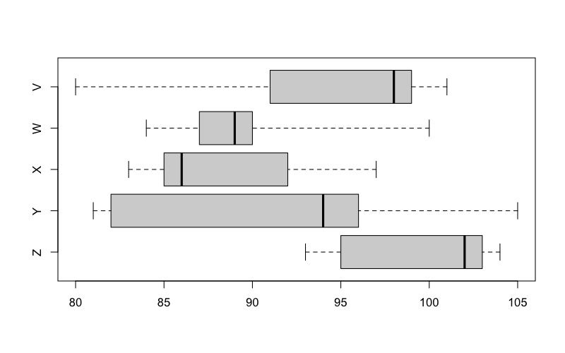

    1. Which sample contains the largest value?
    2. Which sample contains the smallest value?
    3. Which sample has the largest median?
    4. Which sample has the smallest median?
    5. Which sample has the largest IQR?
    6. Which sample has the smallest IQR?

#### Solution

#### Question

43. Five different populations were sampled, and the measurements were visualized as five [boxplots](https://en.wikipedia.org/wiki/Box_plot). (Note: typical boxplots indicate outliers with dots. For simplicity, these boxplots include all outliers in the whiskers.)

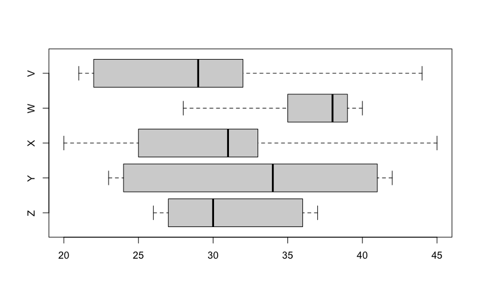

    1. Which sample contains the largest value?
    2. Which sample contains the smallest value?
    3. Which sample has the largest median?
    4. Which sample has the smallest median?
    5. Which sample has the largest IQR?
    6. Which sample has the smallest IQR?

#### Solution

#### Question

44. Five different populations were sampled, and the measurements were visualized as five [boxplots](https://en.wikipedia.org/wiki/Box_plot). (Note: typical boxplots indicate outliers with dots. For simplicity, these boxplots include all outliers in the whiskers.)

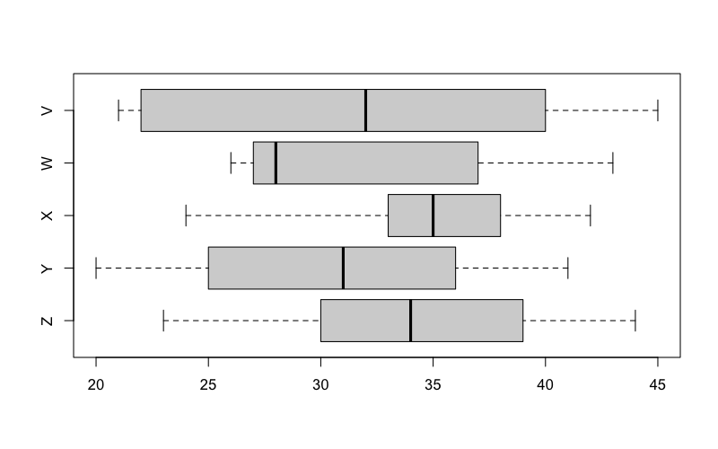

    1. Which sample contains the largest value?
    2. Which sample contains the smallest value?
    3. Which sample has the largest median?
    4. Which sample has the smallest median?
    5. Which sample has the largest IQR?
    6. Which sample has the smallest IQR?

#### Solution

#### Question

45. Five different populations were sampled, and the measurements were visualized as five [boxplots](https://en.wikipedia.org/wiki/Box_plot). (Note: typical boxplots indicate outliers with dots. For simplicity, these boxplots include all outliers in the whiskers.)

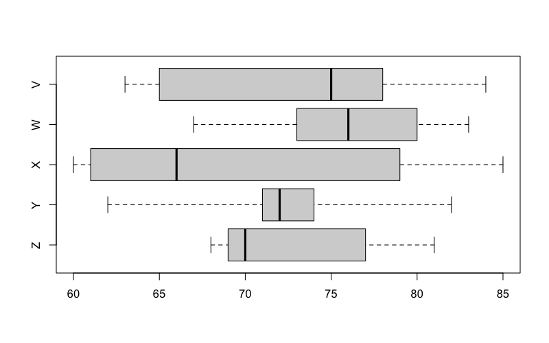

    1. Which sample contains the largest value?
    2. Which sample contains the smallest value?
    3. Which sample has the largest median?
    4. Which sample has the smallest median?
    5. Which sample has the largest IQR?
    6. Which sample has the smallest IQR?

#### Solution

#### Question

46. Five different populations were sampled, and the measurements were visualized as five [boxplots](https://en.wikipedia.org/wiki/Box_plot). (Note: typical boxplots indicate outliers with dots. For simplicity, these boxplots include all outliers in the whiskers.)

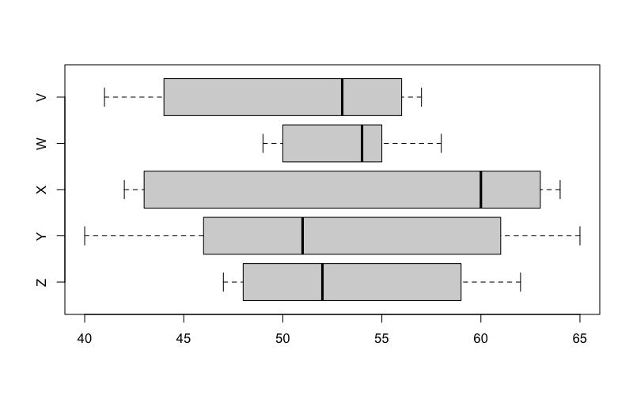

    1. Which sample contains the largest value?
    2. Which sample contains the smallest value?
    3. Which sample has the largest median?
    4. Which sample has the smallest median?
    5. Which sample has the largest IQR?
    6. Which sample has the smallest IQR?

#### Solution

#### Question

47. Five different populations were sampled, and the measurements were visualized as five [boxplots](https://en.wikipedia.org/wiki/Box_plot). (Note: typical boxplots indicate outliers with dots. For simplicity, these boxplots include all outliers in the whiskers.)

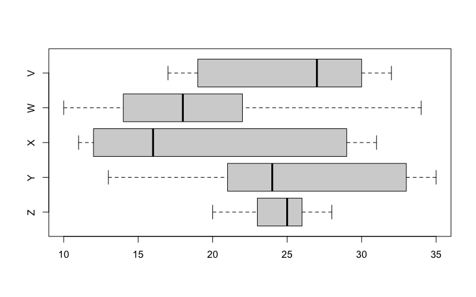

    1. Which sample contains the largest value?
    2. Which sample contains the smallest value?
    3. Which sample has the largest median?
    4. Which sample has the smallest median?
    5. Which sample has the largest IQR?
    6. Which sample has the smallest IQR?

#### Solution

#### Question

48. Five different populations were sampled, and the measurements were visualized as five [boxplots](https://en.wikipedia.org/wiki/Box_plot). (Note: typical boxplots indicate outliers with dots. For simplicity, these boxplots include all outliers in the whiskers.)

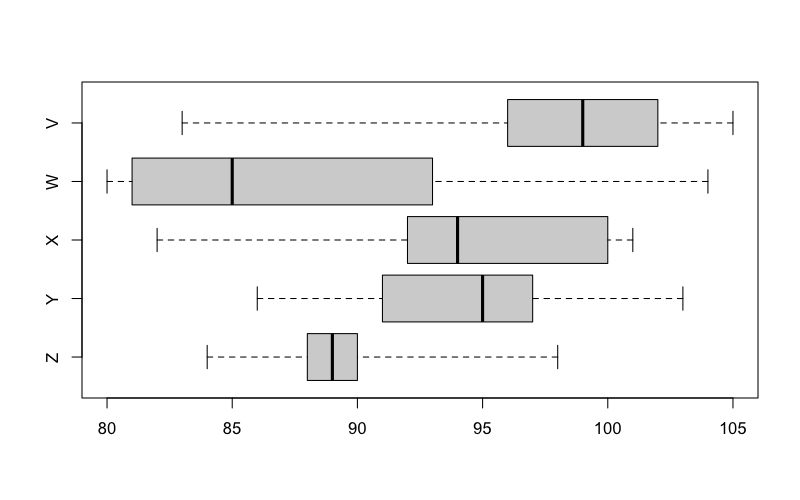

    1. Which sample contains the largest value?
    2. Which sample contains the smallest value?
    3. Which sample has the largest median?
    4. Which sample has the smallest median?
    5. Which sample has the largest IQR?
    6. Which sample has the smallest IQR?

#### Solution

#### Question

49. Five different populations were sampled, and the measurements were visualized as five [boxplots](https://en.wikipedia.org/wiki/Box_plot). (Note: typical boxplots indicate outliers with dots. For simplicity, these boxplots include all outliers in the whiskers.)

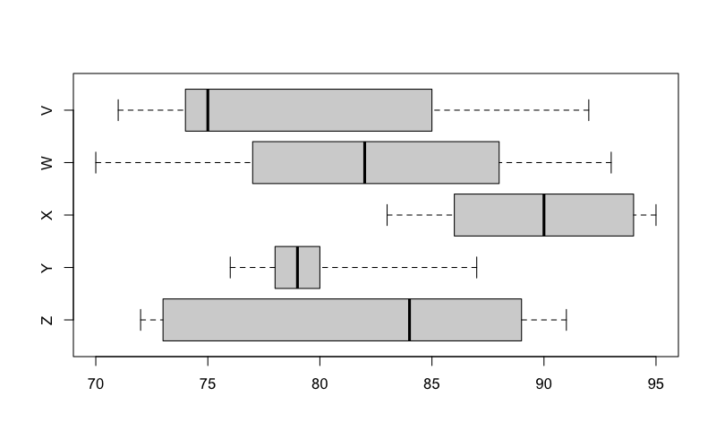

    1. Which sample contains the largest value?
    2. Which sample contains the smallest value?
    3. Which sample has the largest median?
    4. Which sample has the smallest median?
    5. Which sample has the largest IQR?
    6. Which sample has the smallest IQR?

#### Solution

#### Question

50. Five different populations were sampled, and the measurements were visualized as five [boxplots](https://en.wikipedia.org/wiki/Box_plot). (Note: typical boxplots indicate outliers with dots. For simplicity, these boxplots include all outliers in the whiskers.)

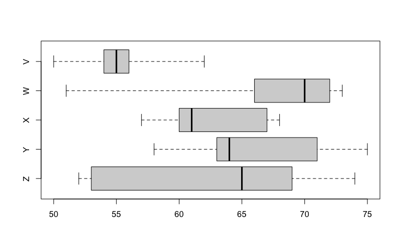

    1. Which sample contains the largest value?
    2. Which sample contains the smallest value?
    3. Which sample has the largest median?
    4. Which sample has the smallest median?
    5. Which sample has the largest IQR?
    6. Which sample has the smallest IQR?

#### Solution